# CS 422: Homework #3

Tiffany Wong, Illinois Institute of Technology

```r
# import dplyr package
# install.packages("dplyr")
library("dplyr")
```

```r
library("rpart")
library("rpart.plot")

# install.packages("ISLR")
library(ISLR)

# get 'random' seed to seeds the pseudo-random number generator for reproducibility
set.seed(1122)

# sample() picks 352 random numbers between 1 and the total number of rows in the Auto dataset, without replacement
index <- sample(1:nrow(Auto), 0.95*dim(Auto)[1])

# training df
train.df <- Auto[index, ]

# testing df
test.df <- Auto[-index, ]
```

## Part 1-A

```r
# get rid of name column
train.df = subset(train.df, select = -c(name))

# create a model with new train.df
model <- lm(mpg ~ ., data=train.df)

summary(model)
```

```
##
## Call:
## lm(formula = mpg ~ ., data = train.df)
##
## Residuals:
##     Min      1Q  Median      3Q     Max
## -9.6805 -2.1786 -0.0977  1.9180 13.0364
##
## Coefficients:
##                Estimate Std. Error t value Pr(>|t|)
## (Intercept)  -1.660e+01  4.780e+00  -3.472 0.000578 ***
## cylinders    -5.235e-01  3.340e-01  -1.567 0.117947
## displacement  2.042e-02  7.760e-03   2.632 0.008857 **
## horsepower   -1.750e-02  1.424e-02  -1.229 0.219908
## weight       -6.416e-03  6.785e-04  -9.457  < 2e-16 ***
## acceleration  8.742e-02  1.031e-01   0.848 0.396859
## year          7.383e-01  5.259e-02  14.039  < 2e-16 ***
## origin        1.516e+00  2.893e-01   5.240 2.73e-07 ***
## ---
## Signif. codes:  0 '***' 0.001 '**' 0.01 '*' 0.05 '.' 0.1 ' ' 1
##
## Residual standard error: 3.367 on 364 degrees of freedom
## Multiple R-squared:  0.817,  Adjusted R-squared:  0.8135
## F-statistic: 232.2 on 7 and 364 DF,  p-value: < 2.2e-16
```

```r
# goodies from model
# names(model)
```

### Part 1-A(i)

1. Why is using name as a predictor not a reasonable thing to do?

Using name as a predictor isn’t reasonable because there wouldn’t be any correlation between the name of the car with the miles per gallon in a car with simply numbers. Essentially, there can’t be any correlation detected between letters and a number.

### Part 1-A(ii)

```r
n <- dim(train.df)[1]
p <- dim(train.df)[2] - 1
RSS  <- sum((train.df$mpg - model$fit)^2)
RSE  <- sqrt(1/(n-p-1)*RSS) #
TSS  <- sum((train.df$mpg - mean(train.df$mpg))^2)
F    <- ((TSS - RSS)/3)/(RSS/(n-p-1))
R.sq <- cor(train.df$mpg, model$fit)^2

print(paste("R2 = ", R.sq))
```

```
## [1] "R2 =  0.817033618528202"
```

```r
print(paste("RSE = ", RSE))
```

```
## [1] "RSE =  3.36691839200609"
```

```r
print(paste("RMSE = ", sqrt(RSS/n)))
```

```
## [1] "RMSE =  3.33051820488739"
```

2. Print the summary of the regression model, and comment on how well the model fits the data by studying the R2, RSE, and RMSE. (Print out the values of R2 , RSE and RMSE.)

The summary of the regression model states that R2=0.8170336. With r-squared meaning variation divided by total variation, this means that this linear regression model explains 81.70% of total variability. The RSE is the relative squared error, and in this case, I got 3.36691 for RSE and 3.3 for RMSE, which is a good measure of accuracy, but it’s scale-dependent.

### Part 1-A(iii)

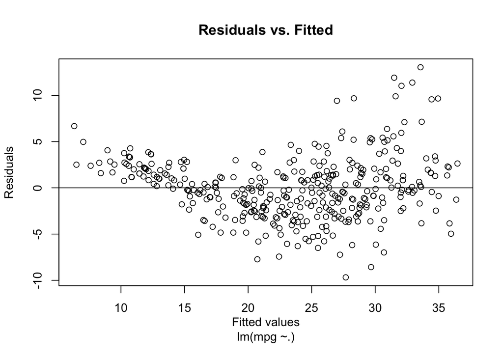

```r
plot(model$fitted.values, model$residuals,
     xlab = "Fitted values\nlm(mpg ~.)",
     ylab="Residuals",
     main="Residuals vs. Fitted");
abline(0, 0)
```

### Part 1-A(iv)

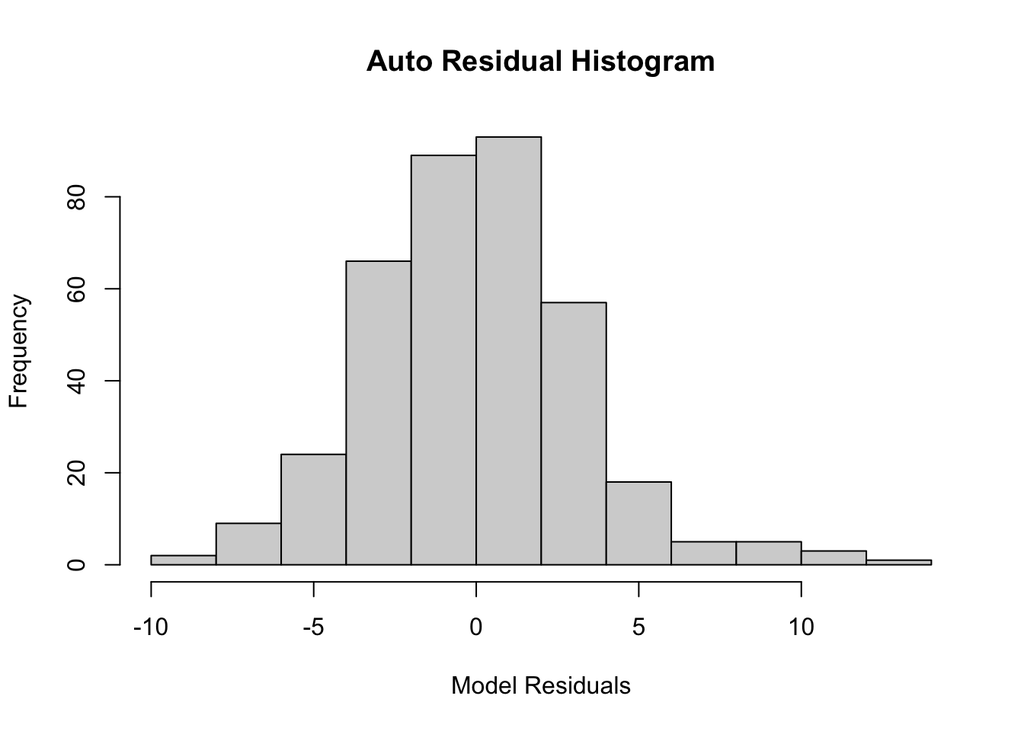

```r
hist(model$residuals, xlab = "Model Residuals",
     main="Auto Residual Histogram")
```

The histogram of residuals of the model does follow a Gaussian distribution, where its concentrated in the middle of the historgram and fans out downward. The distribution of the residuals is normally distributed.

## Part 1-B

```r
summary(model)
```

```
##
## Call:
## lm(formula = mpg ~ ., data = train.df)
##
## Residuals:
##     Min      1Q  Median      3Q     Max
## -9.6805 -2.1786 -0.0977  1.9180 13.0364
##
## Coefficients:
##                Estimate Std. Error t value Pr(>|t|)
## (Intercept)  -1.660e+01  4.780e+00  -3.472 0.000578 ***
## cylinders    -5.235e-01  3.340e-01  -1.567 0.117947
## displacement  2.042e-02  7.760e-03   2.632 0.008857 **
## horsepower   -1.750e-02  1.424e-02  -1.229 0.219908
## weight       -6.416e-03  6.785e-04  -9.457  < 2e-16 ***
## acceleration  8.742e-02  1.031e-01   0.848 0.396859
## year          7.383e-01  5.259e-02  14.039  < 2e-16 ***
## origin        1.516e+00  2.893e-01   5.240 2.73e-07 ***
## ---
## Signif. codes:  0 '***' 0.001 '**' 0.01 '*' 0.05 '.' 0.1 ' ' 1
##
## Residual standard error: 3.367 on 364 degrees of freedom
## Multiple R-squared:  0.817,  Adjusted R-squared:  0.8135
## F-statistic: 232.2 on 7 and 364 DF,  p-value: < 2.2e-16
```

### Part 1-B(ii)

```r
# get rid of name column
train.df = subset(train.df, select = -c(cylinders, displacement, horsepower, acceleration))

# create a model with new train.df
model2 <- lm(mpg ~ ., data=train.df)

summary(model2)
```

```
##
## Call:
## lm(formula = mpg ~ ., data = train.df)
##
## Residuals:
##      Min       1Q   Median       3Q      Max
## -10.0433  -2.1120  -0.0448   1.6867  13.2596
##
## Coefficients:
##               Estimate Std. Error t value Pr(>|t|)
## (Intercept) -1.731e+01  4.123e+00  -4.197 3.39e-05 ***
## weight      -5.973e-03  2.657e-04 -22.481  < 2e-16 ***
## year         7.448e-01  4.983e-02  14.946  < 2e-16 ***
## origin       1.223e+00  2.701e-01   4.525 8.15e-06 ***
## ---
## Signif. codes:  0 '***' 0.001 '**' 0.01 '*' 0.05 '.' 0.1 ' ' 1
##
## Residual standard error: 3.389 on 368 degrees of freedom
## Multiple R-squared:  0.8126, Adjusted R-squared:  0.8111
## F-statistic: 531.8 on 3 and 368 DF,  p-value: < 2.2e-16
```

```r
n <- dim(train.df)[1]
p <- dim(train.df)[2] - 1
RSS  <- sum((train.df$mpg - model2$fit)^2)
RSE  <- sqrt(1/(n-p-1)*RSS) #
TSS  <- sum((train.df$mpg - mean(train.df$mpg))^2)
F    <- ((TSS - RSS)/3)/(RSS/(n-p-1))
R.sq <- cor(train.df$mpg, model2$fit)^2

print(paste("R2 = ", R.sq))
```

```
## [1] "R2 =  0.81258059379783"
```

```r
print(paste("RSE = ", RSE))
```

```
## [1] "RSE =  3.38907360996063"
```

```r
print(paste("RMSE = ", sqrt(RSS/n)))
```

```
## [1] "RMSE =  3.37080353826561"
```

The summary of the regression model states that R2=0.81258059379783 With r-squared meaning variation divided by total variation, this means that this linear regression model explains 81.25% of total variability. The RSE is the relative squared error, and in this case, I got 3.38907 for RSE and 3.370803 for RMSE, which is a good measure of accuracy, but it’s scale-dependent.

### Part 1-B(iii)

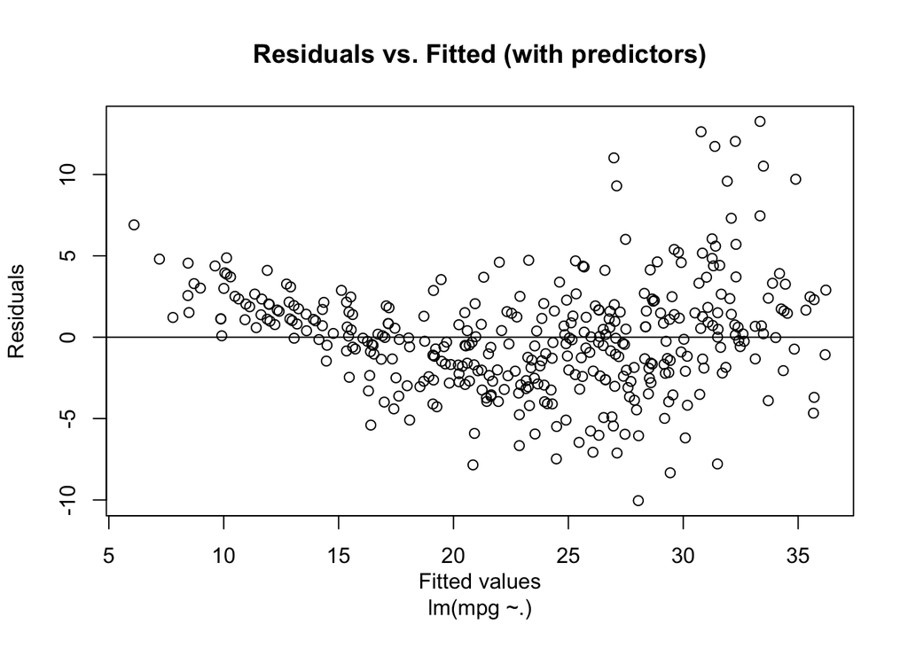

```r
plot(model2$fitted.values, model2$residuals,
     xlab = "Fitted values\nlm(mpg ~.)",
     ylab="Residuals",
     main="Residuals vs. Fitted (with predictors)");
abline(0, 0)
```

### Part 1-B(iv)

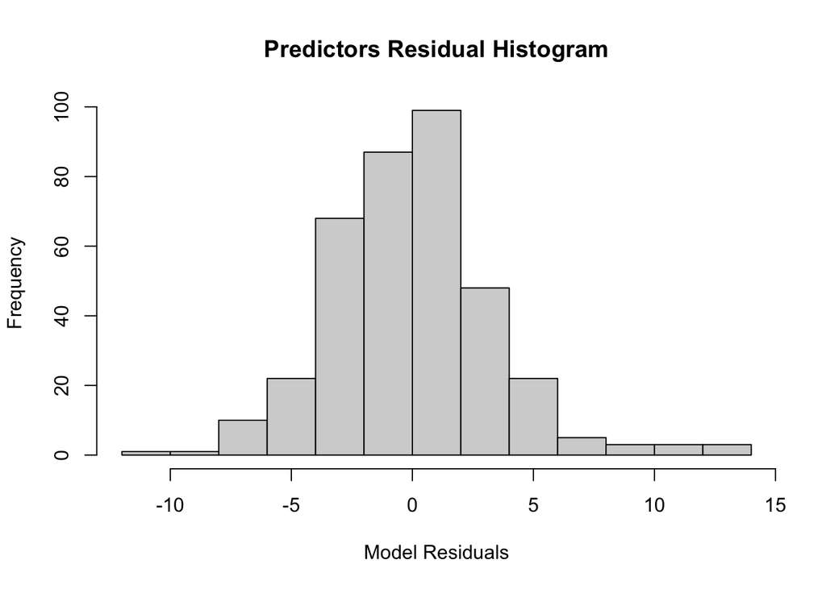

```r
hist(model2$residuals, xlab = "Model Residuals",
     main="Predictors Residual Histogram")
```

The histogram of residuals of the model does follow a Gaussian distribution, where its concentrated in the middle of the historgram and fans out downward. The distribution of the residuals is normally distributed, pretty much the same as part A(iv).

### Part 1-B(v)

Comparing the summaries of the model produced in (a) and in (b), including residual analysis of each model. Which model do you think is better, and why?

```r
summary(model)
```

```
##
## Call:
## lm(formula = mpg ~ ., data = train.df)
##
## Residuals:
##     Min      1Q  Median      3Q     Max
## -9.6805 -2.1786 -0.0977  1.9180 13.0364
##
## Coefficients:
##                Estimate Std. Error t value Pr(>|t|)
## (Intercept)  -1.660e+01  4.780e+00  -3.472 0.000578 ***
## cylinders    -5.235e-01  3.340e-01  -1.567 0.117947
## displacement  2.042e-02  7.760e-03   2.632 0.008857 **
## horsepower   -1.750e-02  1.424e-02  -1.229 0.219908
## weight       -6.416e-03  6.785e-04  -9.457  < 2e-16 ***
## acceleration  8.742e-02  1.031e-01   0.848 0.396859
## year          7.383e-01  5.259e-02  14.039  < 2e-16 ***
## origin        1.516e+00  2.893e-01   5.240 2.73e-07 ***
## ---
## Signif. codes:  0 '***' 0.001 '**' 0.01 '*' 0.05 '.' 0.1 ' ' 1
##
## Residual standard error: 3.367 on 364 degrees of freedom
## Multiple R-squared:  0.817,  Adjusted R-squared:  0.8135
## F-statistic: 232.2 on 7 and 364 DF,  p-value: < 2.2e-16
```

```r
summary(model2)
```

```
##
## Call:
## lm(formula = mpg ~ ., data = train.df)
##
## Residuals:
##      Min       1Q   Median       3Q      Max
## -10.0433  -2.1120  -0.0448   1.6867  13.2596
##
## Coefficients:
##               Estimate Std. Error t value Pr(>|t|)
## (Intercept) -1.731e+01  4.123e+00  -4.197 3.39e-05 ***
## weight      -5.973e-03  2.657e-04 -22.481  < 2e-16 ***
## year         7.448e-01  4.983e-02  14.946  < 2e-16 ***
## origin       1.223e+00  2.701e-01   4.525 8.15e-06 ***
## ---
## Signif. codes:  0 '***' 0.001 '**' 0.01 '*' 0.05 '.' 0.1 ' ' 1
##
## Residual standard error: 3.389 on 368 degrees of freedom
## Multiple R-squared:  0.8126, Adjusted R-squared:  0.8111
## F-statistic: 531.8 on 3 and 368 DF,  p-value: < 2.2e-16
```

I think the first model is better becasue it has a greater R-squared value, where the first model (with all the variables) has a R-squared value of 0.817 and the second model (with the 3 predictor variables) has a R-sqaured value of 0.8126. With r-squared meaning variation divided by total variation, this means that the first linear regression model explains 81.7% of total variability while the second model only explains 81.27% of total variability.

## Part 1-C

```r
# get rid of all columns except mpg, year, weight, origin column
test.df = subset(test.df, select = c(mpg, year, weight, origin))
# names(test.df)

predicted <- predict(model2, newdata=test.df)

df <- data.frame(predict = predict.lm(model2, test.df, interval = 'confidence', level = 0.95), real = test.df$mpg)
df
```

|  | predict.fit | predict.lwr | predict.upr | real |
| --- | --- | --- | --- | --- |
| 23 | 23.087261 | 22.298650 | 23.87587 | 25.0 |
| 86 | 13.796155 | 13.202787 | 14.38952 | 13.0 |
| 96 | 8.713373 | 7.789197 | 9.63755 | 12.0 |
| 111 | 26.520256 | 25.711209 | 27.32930 | 22.0 |
| 121 | 22.377070 | 21.874010 | 22.88013 | 19.0 |
| 140 | 11.327620 | 10.541322 | 12.11392 | 14.0 |
| 153 | 20.278919 | 19.850586 | 20.70725 | 19.0 |
| 161 | 16.438462 | 15.923494 | 16.95343 | 17.0 |
| 176 | 29.427242 | 28.827257 | 30.02723 | 29.0 |
| 178 | 24.905895 | 24.492442 | 25.31935 | 23.0 |

[output cut: 10 more lines]

## Part 1-D

```r
df$Matches <- as.numeric(apply(df, MARGIN = 1, FUN = function(x) x[4] >= x[2] & x[4] <= x[3]))
df
```

|  | predict.fit | predict.lwr | predict.upr | real | Matches |
| --- | --- | --- | --- | --- | --- |
| 23 | 23.087261 | 22.298650 | 23.87587 | 25.0 | 0 |
| 86 | 13.796155 | 13.202787 | 14.38952 | 13.0 | 0 |
| 96 | 8.713373 | 7.789197 | 9.63755 | 12.0 | 0 |
| 111 | 26.520256 | 25.711209 | 27.32930 | 22.0 | 0 |
| 121 | 22.377070 | 21.874010 | 22.88013 | 19.0 | 0 |
| 140 | 11.327620 | 10.541322 | 12.11392 | 14.0 | 0 |
| 153 | 20.278919 | 19.850586 | 20.70725 | 19.0 | 0 |
| 161 | 16.438462 | 15.923494 | 16.95343 | 17.0 | 0 |
| 176 | 29.427242 | 28.827257 | 30.02723 | 29.0 | 1 |
| 178 | 24.905895 | 24.492442 | 25.31935 | 23.0 | 0 |

[output cut: 10 more lines]

```r
match_count <- sum(df['Matches'])


print(paste("Total observations correctly predicted: ", match_count))
```

```
## [1] "Total observations correctly predicted:  7"
```

## Part 1-E

```r
predicted <- predict(model2, newdata=test.df)

df2 <- data.frame(predict = predict.lm(model2, test.df, interval = 'prediction', level = 0.95), real = test.df$mpg)
df2
```

|  | predict.fit | predict.lwr | predict.upr | real |
| --- | --- | --- | --- | --- |
| 23 | 23.087261 | 16.376384 | 29.79814 | 25.0 |
| 86 | 13.796155 | 7.105412 | 20.48690 | 13.0 |
| 96 | 8.713373 | 1.985219 | 15.44153 | 12.0 |
| 111 | 26.520256 | 19.806946 | 33.23357 | 22.0 |
| 121 | 22.377070 | 15.693730 | 29.06041 | 19.0 |
| 140 | 11.327620 | 4.617014 | 18.03823 | 14.0 |
| 153 | 20.278919 | 13.600788 | 26.95705 | 19.0 |
| 161 | 16.438462 | 9.754215 | 23.12271 | 17.0 |
| 176 | 29.427242 | 22.735908 | 36.11858 | 29.0 |
| 178 | 24.905895 | 18.228702 | 31.58309 | 23.0 |

[output cut: 10 more lines]

```r
df2$Matches <- as.numeric(apply(df2, MARGIN = 1, FUN = function(x) x[4] >= x[2] & x[4] <= x[3]))
df2
```

|  | predict.fit | predict.lwr | predict.upr | real | Matches |
| --- | --- | --- | --- | --- | --- |
| 23 | 23.087261 | 16.376384 | 29.79814 | 25.0 | 1 |
| 86 | 13.796155 | 7.105412 | 20.48690 | 13.0 | 1 |
| 96 | 8.713373 | 1.985219 | 15.44153 | 12.0 | 1 |
| 111 | 26.520256 | 19.806946 | 33.23357 | 22.0 | 1 |
| 121 | 22.377070 | 15.693730 | 29.06041 | 19.0 | 1 |
| 140 | 11.327620 | 4.617014 | 18.03823 | 14.0 | 1 |
| 153 | 20.278919 | 13.600788 | 26.95705 | 19.0 | 1 |
| 161 | 16.438462 | 9.754215 | 23.12271 | 17.0 | 1 |
| 176 | 29.427242 | 22.735908 | 36.11858 | 29.0 | 1 |
| 178 | 24.905895 | 18.228702 | 31.58309 | 23.0 | 1 |

[output cut: 10 more lines]

```r
match_count <- sum(df2['Matches'])


print(paste("Total observations correctly predicted: ", match_count))
```

```
## [1] "Total observations correctly predicted:  20"
```

## Part 1-F

### Part 1-F(i)

Which of (d) or (e) results in more matches?

Part e’s results get more matches, all of the values are in the predicted interval.

### Part 1-F(ii)

Why?

Part e’s results get more matches because the prediction interval predicts in what range a future individual observation will fall, where a confidence interval shows the likely range of values associated with the mean. It’s the difference between predicting where a value will end up versus giving a range based on a singular summary value.